# Tutorial 3: GAMs

STA5090Z Advanced Topics in Regression

Author

Birgit Erni

Published

August 4, 2026

# Penalized Likelihood Example

Here is some code for fitting a spline using penalized maximum likelihood (single term).

First, I simulate some Poisson data, define the likelihood and the penalized likelihood and minimize this (negative penalized likelihood).

- Can you adapt this to use P-splines instead of penalized B-splines?
- Add GCV to optimize the smoothing parameter?
- What would happen if you would also estimate the smoothing parameter, as part of optimizing?

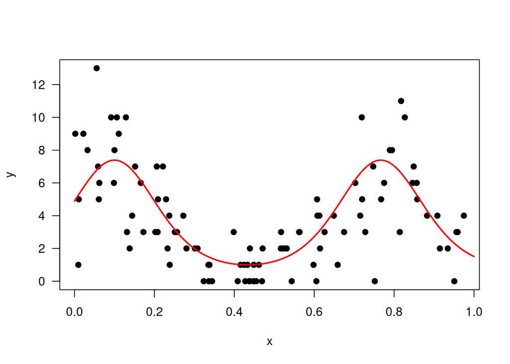

```r
x <- runif(100, 0, 1)

lp <- 1 + sin(3 * pi * (x - 0.6))

mu <- exp(lp)

y <- rpois(100, lambda = mu)

plot(y ~ x, las = 1, pch = 19)

xrange <- seq(0, 1, length = 1000)
mm <- exp(1 + sin(3 * pi * (xrange - 0.6)))
lines(mm ~ xrange, lwd = 2, col = "red")
```

```r
library(splines)

# negative log-likelihood

# set up B-spline basis matrix
BX <- bs(x, df = 6, intercept = TRUE)

nll <- function(p, x, y, BX) {
  linp <- BX %*% p
  lam <- exp(linp)
  ll <- sum( dpois(y, lambda = lam, log = TRUE))
  return(-ll)
}

# penalty matrix, intercept not penalized
P <- diag(6)
P[1, 1] = 0

# penalized negative log-likelihood
pnll <- function(beta, x, y, BX, sp, P) {

  pen <- t(beta) %*% P %*% beta
  pnll <- nll(p = beta, x, y, BX) + sp * pen

  return(pnll)
}

init <- rep(0.5, times = 6)

(out <- nlm(pnll, p = init, x = x, y = y, BX = BX, sp = 1, P = P))
```

```
$minimum
[1] 212.5027

$estimate
[1]  1.8117470  2.5889019 -0.2337665  0.5849219  2.6686851  0.5609857

$gradient
[1]  8.345729e-06 -1.756526e-07  1.003286e-05 -1.853095e-05  1.384510e-07
[6] -5.883294e-06

$code
[1] 1

$iterations
[1] 15
```

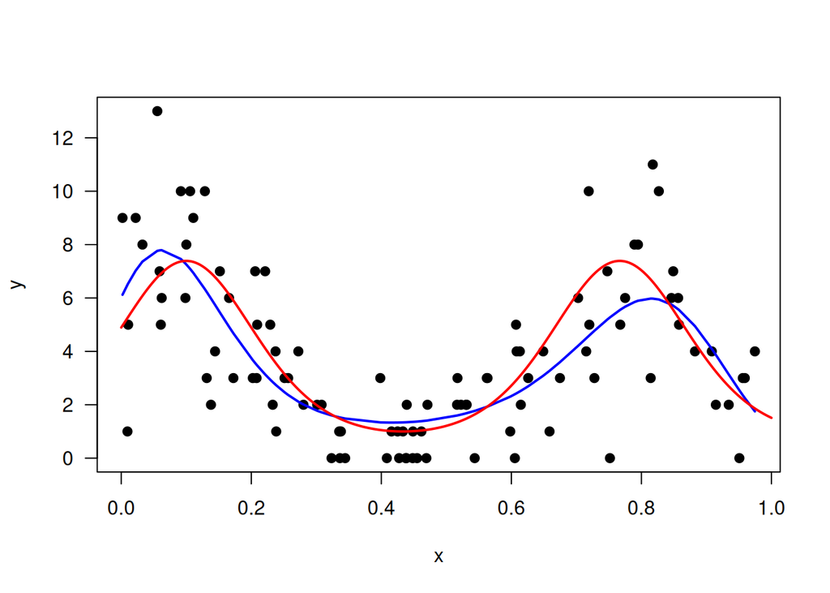

```r
bhat <- out$estimate

lhat <- exp(BX %*% bhat)

yo <- y[order(x)]
xo <- x[order(x)]
lhato <- lhat[order(x)]

plot(yo ~ xo, pch = 19, ylab = "y", xlab = "x", las = 1)
lines(lhato ~ xo, col = "blue", lwd = 2)
lines(mm ~ xrange, lwd = 2, col = "red")
```

The above code did not use the IRLS algorithm to maximise the likelihood. IRLS might be slightly more efficient.

I fixed the smoothing parameter at $\lambda = 1$. The next step would be to use GCV to find an optimal smoothing parameter.

Also, the blue line should be a lot smoother (this is a problem with my way of plotting, not with the penalized likelihood).

# Question 1

Using the bomsoi data from the DAAG library:

1. Reproduce the plots in the slides at the beginning of this section (use gam in mgcv).
2. For the model
   $$y_i = \beta_0 + f_1(SOI_i) + f_2(Year_i) + e_i$$
   program a backfitting algorithm to estimate the GAM parameters for SOI and year. You can use `smooth.spline()` (`stats`).

# Question 2

Explore the ‘gam’ function in ‘mgcv’. This is important, because when we write up our methods for an analysis we need to state exactly what settings were used (in case somebody else wants to replicate this in some other software package, e.g. SAS).

1. What happens if I add an $s(x)$ term to a model? How are knots selected, what type of basis is chosen, are the terms penalized.
2. What algorithm is used to fit the model (default)?
3. How does penalization work? How can you determine the amount of penalization? What is the `sp` parameter?
4. Can you get to the penalty matrices using the option `fit = FALSE`?
5. Does it use penalized IRWLS? Does it use a backfitting algorithm?
6. In the summary output, what are `edf`? (`?summary.gam`)
7. How can you fit terms that are not penalized?

# IRLS - Exponential Example

Wood pg. 66, 138 (first edition)

The response is time to death in weeks from diagnosis, the predictor variable is log10(initial white blood cell count) for seventeen patients suffering from leukemia (Dobson).

Assume an exponential distribution for time to death, with

$$\log(\mu_i) = \beta_0 + \beta_1 x_i$$

$$w_i = \frac{1}{V(y_i)} \left(\frac{d\eta_i}{d\mu_i}\right)^2$$

$$\hat{\beta} = (X'WX)^{-1}X'Wy$$

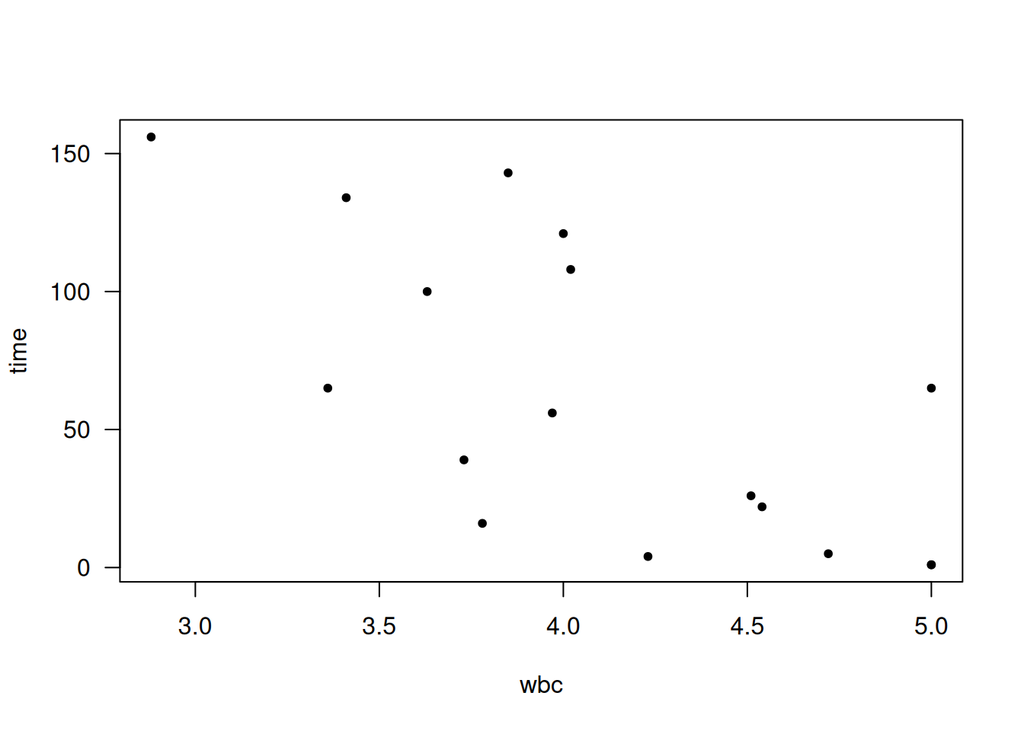

```r
library(dobson)
leukemia

plot(time ~ wbc, data = leukemia, las = 1, pch = 20)
```

$$\log(\mu_i) = \beta_0 + \beta_1 x$$

$$w_i = 1$$

$$z_i = X_i \beta + (y_i - \mu_i) / \mu_i$$

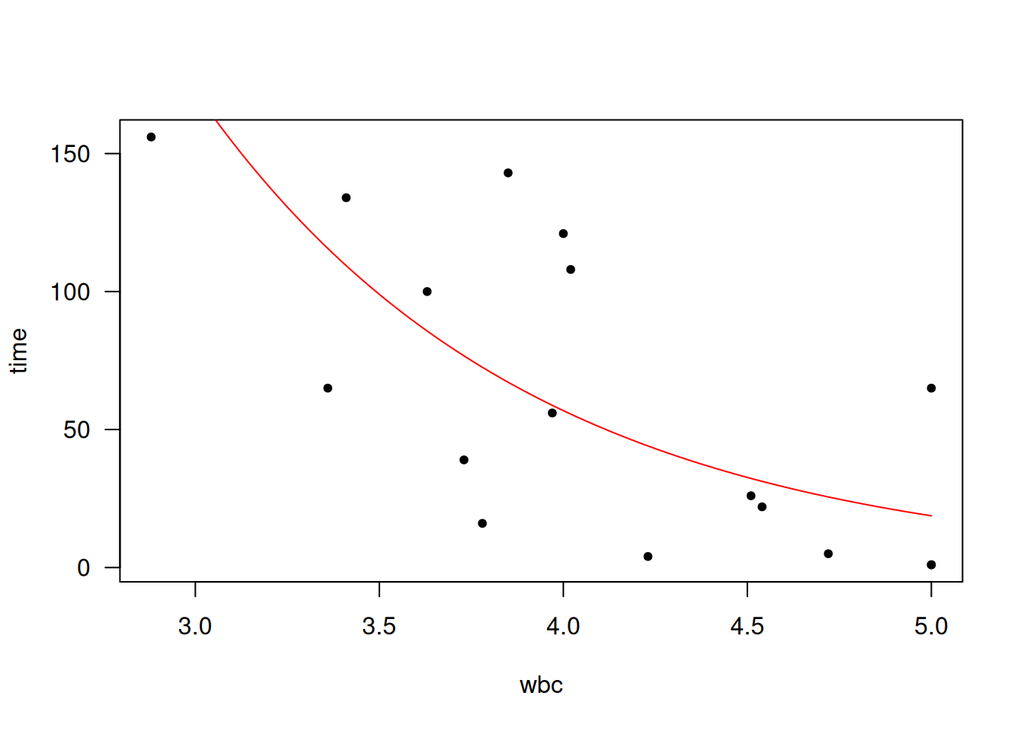

```r
y <- leukemia$time
x <- leukemia$wbc
n <- length(y)
X <- cbind(rep(1, times = 1), x)

# starting values
beta <- c(5, -1)


for (i in 1:50) {
  wii <- rep(1, times = n)
  W <- diag(wii)
  mu <- exp(X %*% beta)
  zz <- X %*% beta + (y - mu) / mu
  beta <- solve(t(X) %*% W %*% X) %*% t(X) %*% W %*% zz
  print(beta)
}

xrange <- seq(min(x), max(x), length = 100)
Xpred <- cbind(rep(1, times = 100), xrange)
Ypred <- exp(Xpred %*% beta)
Ypred

plot(time ~ wbc, data = leukemia, las = 1, pch = 20)
lines(xrange,  Ypred, col = "red")
```

# Question 3

Simulate some data

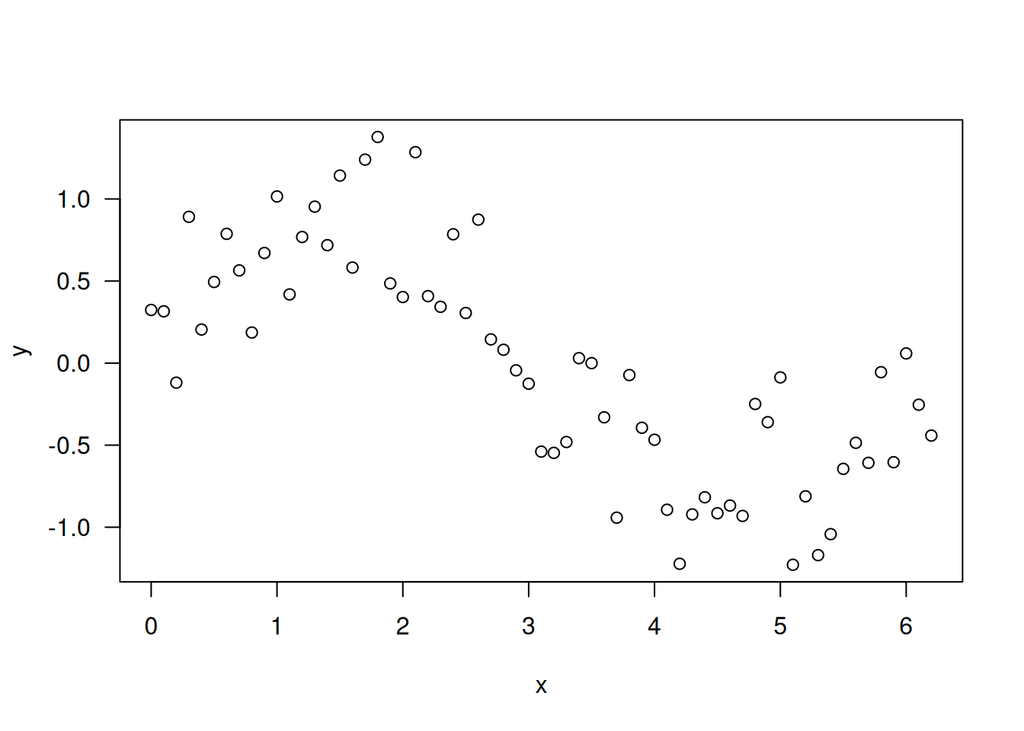

```r
x <- seq(0, 2*pi, by = 0.1)
y <- sin(x) + rnorm(length(x), 0, sd = sd(sin(x) / 2))
plot(y ~ x, las = 1)
```

# Question 4: Simulate splines

1. Choose a random set of beta coefficients from $N(0, \sigma^2)$, and plot the resulting splines (10 to 20). One could see this as the ‘prior’ distribution of splines (in a Bayesian context).
2. Obtain the Covariance matrix for the fitted spline (mgcv) coefficients, and simulate 10 to 20 splines.

# Question 5: mcycle

The `mcycle` data in library `MASS` are measurements of head acceleration in a simulated motorcycle accident, used to test crash helmets. This is one of the classical spline data sets you will often see in textbooks and examples.

Fit a spline to the `mcycle` data, using `s()` in `mgcv`. Then try and reproduce what `s()` is doing exactly, by setting up the basis functions and fitting / penalizing without the `gam` functionality.

# Question 6: Penalization in mgcv

Compare the different ways to penalize with `gam` and `s()` (df, knots, `sp`, lambda, no penalty, `H`).

# Question 7: Cairo Temperatures

Fit an appropriate GAM to the `cairo` data set (in `gamair`). The data set contains daily temperature over nearly a decade. Your model should include a long-term trend and seasonal changes. You don’t have to worry about autocorrelation here. Illustrate with confidence intervals.

# Question 8: Surface

Use the functions in `mgcv` to estimate the following surface. Try tensor product and thin-plate splines.

```r
gamSim(eg = 2, n = 500, dist = "normal", scale = 0.1, verbose = TRUE)
```

# Explore

1. Marra, G. and Radice, R. (2010) “Penalised regression splines: theory and application to medical research,” Statistical Methods in Medical Research, 19(2), pp. 107–125. https://doi.org/10.1177/0962280208096688
2. Confidence and prediction intervals for GAMs (see GAM book, Wood)

Wood, S.N. (2006) “On Confidence Intervals for Generalized Additive Models Based on Penalized Regression Splines,” Australian & New Zealand Journal of Statistics, 48(4), pp. 445–464. https://doi.org/10.1111/j.1467-842X.2006.00450.x

3. Write function to fit GAMs using backfitting and penalized likelihood (penalized IRWLS). Compare.